# 140.654 Lab 2: Checking a Logistic Regression Model

Erjia Cui and Elizabeth Colantuoni

## Objectives

The objectives of today’s lab session are:

1. Describe and implement the lorelogram for evaluating dependence in longitudinal designs with binary outcomes.
2. Construct observed vs. fitted plots to evaluate the logistic regression assumptions for the mean of the binary outcome.
3. Evaluate the variance assumption within a logistic regression model.
4. Use DBETAS and DFITS to evaluate the influence of individual observations on the fit of a logistic regression model.

## Introduction

Assumptions of a logistic regression model from most to least important:

1. Independence
2. Mean model correctly specified
3. Variance model correctly specified
4. Few data points don’t have great influence on results

```r
library(ggplot2)
library(dplyr)
library(splines)
load('./../nmes.rdata')
data <- nmes
data[data == '.'] <- NA
```

## Checking Assumptions

### 1. Independence - Lorelogram

The evaluation of independence assumption stems mostly from the design. If the design indicates possible correlations, such as a longitudinal or clustered design, then it is very important to check the independence assumption.

Checking independence in linear and logistic regressions:

- Linear: Calculate residuals $r_{ij}=y_{ij}-\hat{\mu}_{ij}$ and $r_{ik}=y_{ik}-\hat{\mu}_{ik}$. Plot $r_{ij}$ vs $r_{ik}$ and calculate $corr(r_{ij},r_{ik})$
- Logistic: Construct $2\times 2$ table $y_{it}$ vs $y_{it'}$ and calculate $log(OR(y_{it},y_{it'}))$.

#### Schizophrenia example: hallucinations

|  | Jan | Feb | Mar | Apr | May |
| --- | --- | --- | --- | --- | --- |
| Patient 1 | 1 | 0 | 0 | 1 | 0 |
| Patient 2 | 0 | 0 | 0 | 0 | 0 |
| Patient 3 | 1 | 1 | 1 | 0 | 1 |
| … |  |  |  |  |  |
| Patient n | 0 | 0 | 1 | 0 | 1 |

For time points $t$ (Feb) and $t'$ (Apr),

|  | $y_{it'}=0$ | $y_{it'}=1$ |
| --- | --- | --- |
| $y_{it}=0$ | 100 | 20 |
| $y_{it}=1$ | 20 | 100 |

OR=25, logOR=3.2. Then plot the logOR against time difference - this is called **lorelogram.** Later in the course we will discuss the longitudinal models for which lorelogram can be used; we will also discuss GEE approach and random effects logistic regression models.

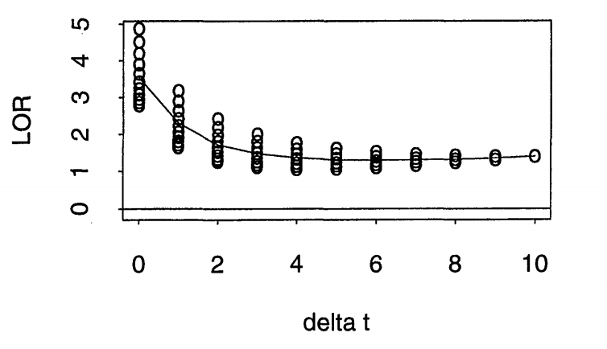

For the remainder of this lab session, we only consider the cross-sectional NMES dataset. We first introduce the dataset, then check the mean model, variance model and influence/outliers.

### National Medical Expenditure Survey (NMES) Dataset

- Outcome: big expenditure defined as total expenditure > 1000 (bigexp)
- Exposure: Major smoking caused disease (mscd)
- Covariate: person’s age
- Dataset: 11,684 people for 40 or older who have smoking data available

```r
data$mscd <- ifelse(data$lc5 + data$chd5 > 0, 1, 0)
data1 <- data[!is.na(data$eversmk),]
data1$bigexp <- ifelse(data1$totalexp > 1000, 1, 0)
```

Fit logistic regression of big medical expenditure vs. age, MSCD and interaction.

```r
mod <- glm(bigexp ~ lastage*mscd, data = data1, family = binomial(link="logit"))
summary.glm(mod)
```

```
##
## Call:
## glm(formula = bigexp ~ lastage * mscd, family = binomial(link = "logit"),
##     data = data1)
##
## Deviance Residuals:
##     Min       1Q   Median       3Q      Max
## -1.6963  -0.9049  -0.7420   1.2814   1.7497
##
## Coefficients:
##               Estimate Std. Error z value Pr(>|z|)
## (Intercept)  -2.387498   0.103237 -23.126  < 2e-16 ***
## lastage       0.027517   0.001666  16.513  < 2e-16 ***
## mscd          3.245759   0.426853   7.604 2.87e-14 ***
## lastage:mscd -0.024223   0.006169  -3.927 8.62e-05 ***
## ---
## Signif. codes:  0 '***' 0.001 '**' 0.01 '*' 0.05 '.' 0.1 ' ' 1
##
## (Dispersion parameter for binomial family taken to be 1)
##
##     Null deviance: 15411  on 11683  degrees of freedom
## Residual deviance: 14255  on 11680  degrees of freedom
## AIC: 14263
##
## Number of Fisher Scoring iterations: 4
```

### 2. Is the Mean Model Correct?

```r
data1 <- data1 %>% mutate(fitted.values = mod$fitted.values,
                         pearson.raw.resid = bigexp-fitted.values,
                         pearson.resid = pearson.raw.resid/sqrt(fitted.values*(1-fitted.values)),
                         dev.resid = summary(mod)$deviance.resid,
                         dev.resid.formula = sign(bigexp-fitted.values)*sqrt(-2*(bigexp*log(fitted.values)+(1-bigexp)*log(1-fitted.values)))) # Also compute the deviance residual by formula and compare results
```

#### 2a. Weatherperson plot: Compare empirical means with estimated values

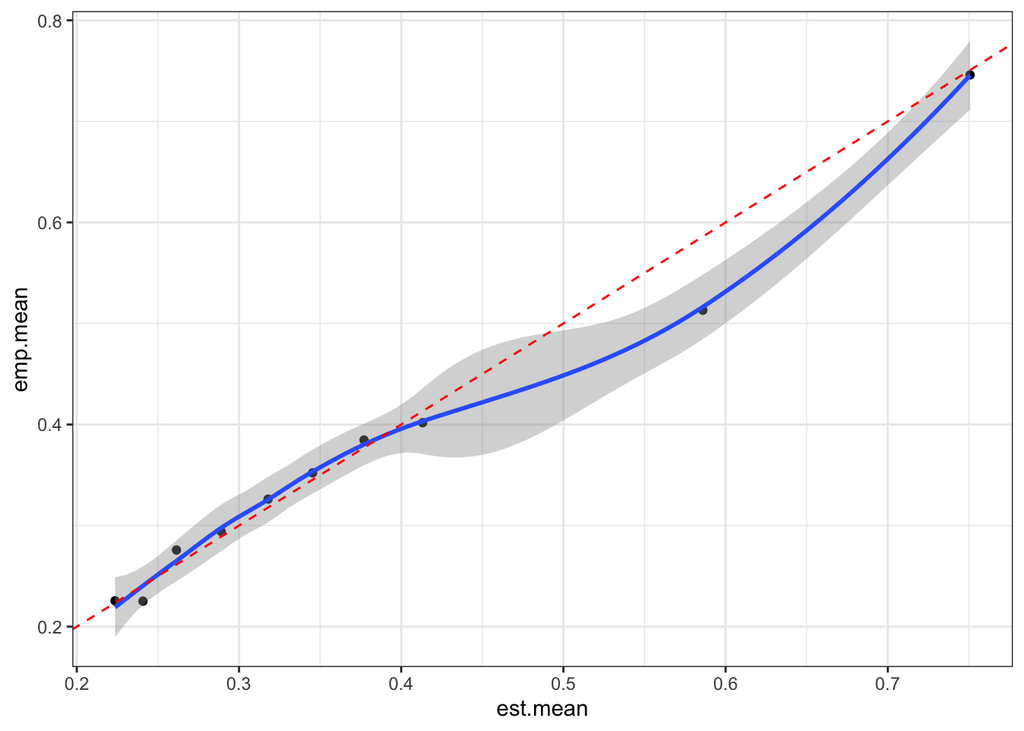

```r
fitted.values.quant <- quantile(data1$fitted.values, seq(0, 1, by = 0.1))
df.wp <- data1 %>% mutate(fitted.values.range = cut(fitted.values, fitted.values.quant, include.lowest=TRUE)) %>%
    group_by(fitted.values.range) %>%
    summarize(emp.mean = mean(bigexp)) %>%
    mutate(est.mean = (fitted.values.quant[-length(fitted.values.quant)] + fitted.values.quant[-1]) / 2)

ggplot(data = df.wp, aes(x = est.mean, y = emp.mean)) +
    theme_bw() +
    geom_point() +
    geom_smooth() +
    geom_abline(intercept = 0, slope = 1, color = "red", linetype = "dashed")
```

The model fits well while the fitted values are <0.4 but less well at extreme values. To explore this we further plot the average of fitted and observed values within each 10% quantile of age, stratified by mscd status.

```r
age.quant <- quantile(data1$lastage, seq(0, 1, by = 0.1))
df.wp.age.mscd <- data1 %>% mutate(age.range = cut(lastage, age.quant, include.lowest = TRUE)) %>%
    group_by(age.range, mscd) %>%
    summarize(emp.mean = mean(bigexp), est.mean = mean(fitted.values))
```

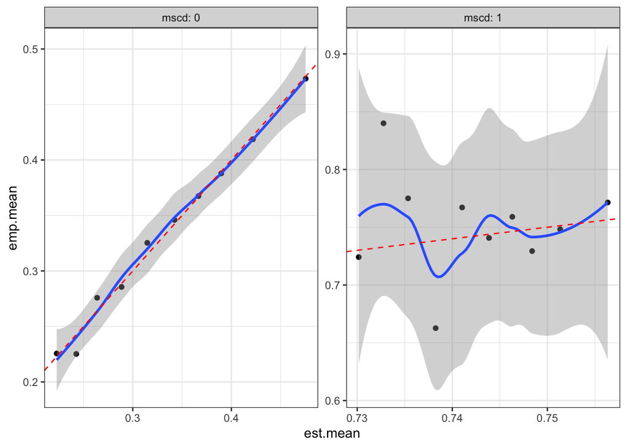

```r
df.wp.age.mscd$age.mean <- rep((age.quant[-length(age.quant)] + age.quant[-1]) / 2, each = 2)

ggplot(data = df.wp.age.mscd, aes(x = est.mean, y = emp.mean)) +
    theme_bw() +
    geom_point() +
    geom_smooth() +
    facet_wrap(~mscd, scales = "free", labeller = label_both) +
    geom_abline(intercept = 0, slope = 1, color = "red", linetype = "dashed")
```

From the plot, we observe a clear difference between the average fitted and observed values when mscd = 1. We next plot the average fitted and observed values vs. age among people with mscd = 1.

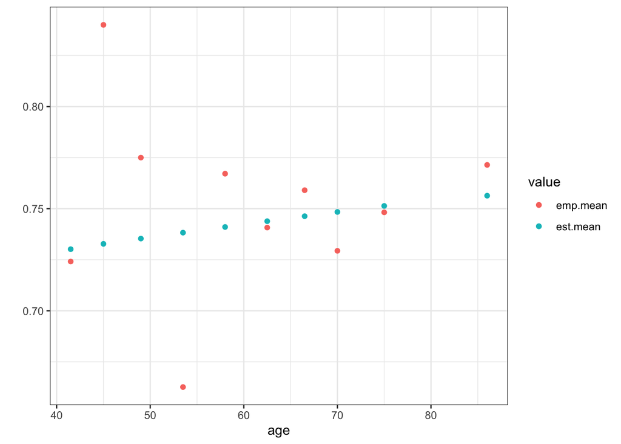

```r
ggplot(data = df.wp.age.mscd %>% filter(mscd == 1), aes(x = age.mean)) +
    theme_bw() +
    geom_point(aes(y = emp.mean, color = "emp.mean")) +
    geom_point(aes(y = est.mean, color = "est.mean")) +
    labs(color = "value", x = "age", y = "")
```

This plot suggests that the model needs some different function for age.

#### 2b. Residuals vs. fitted values

#### Pearson residual

- Similar to linear models, the Pearson residual is defined as
  $$res_i = y_i-\hat{\mu}_i$$
  where $\hat{\mu}_i = \frac{\exp(x_i^t\beta)}{1+\exp(x_i^t\beta)}$.
- Standardized Pearson residual:
  $$sres_i = \frac{y_i-\hat{\mu}_i}{\sqrt{\hat{\mu}_i(1-\hat{\mu}_i)}}.$$
  The standardized residual has approximately mean 0 and variance 1.

#### Deviance residual

- General likelihood for binary outcomes
  $$L = \prod\limits_{i=1}^n L_i = \prod\limits_{i=1}^n \mu_i^{y_i}(1-\mu_i)^{1-y_i},$$
  where $L_i=\mu_i$ if $y_i=1$, $L_i=1-\mu_i$ if $y_i=0$.
- Without any model assumption, the highest possible likelihood corresponding to the $i$-th observation $L_{i,max}=1$, hence the highest possible total likelihood $L_{max}=1$.
- Under logistic regression model, the likelihood corresponding to the $i$-th observation is
  $$L_{i,fitted} = \hat{\mu}_i^{y_i}(1-\hat{\mu}_i)^{1-y_i}$$
- Deviance is the difference of -2*log-likelihood between the fitted model and the saturated model
  $$D=-2(logL_{fitted}-logL_{max}) = -2\sum\limits_{i=1}^n \{y_ilog(\hat{\mu}_i)+(1-y_i)log(1-\hat{\mu}_i)\}$$
- The deviance residual is defined as
  $$d_i=sign(y-\hat{\mu}_i)\sqrt{-2 \{y_i log(\hat{\mu}_i)+(1-y_i)log(1-\hat{\mu}_i)\}}.$$

#### Use Pearson and deviance residuals for model checking

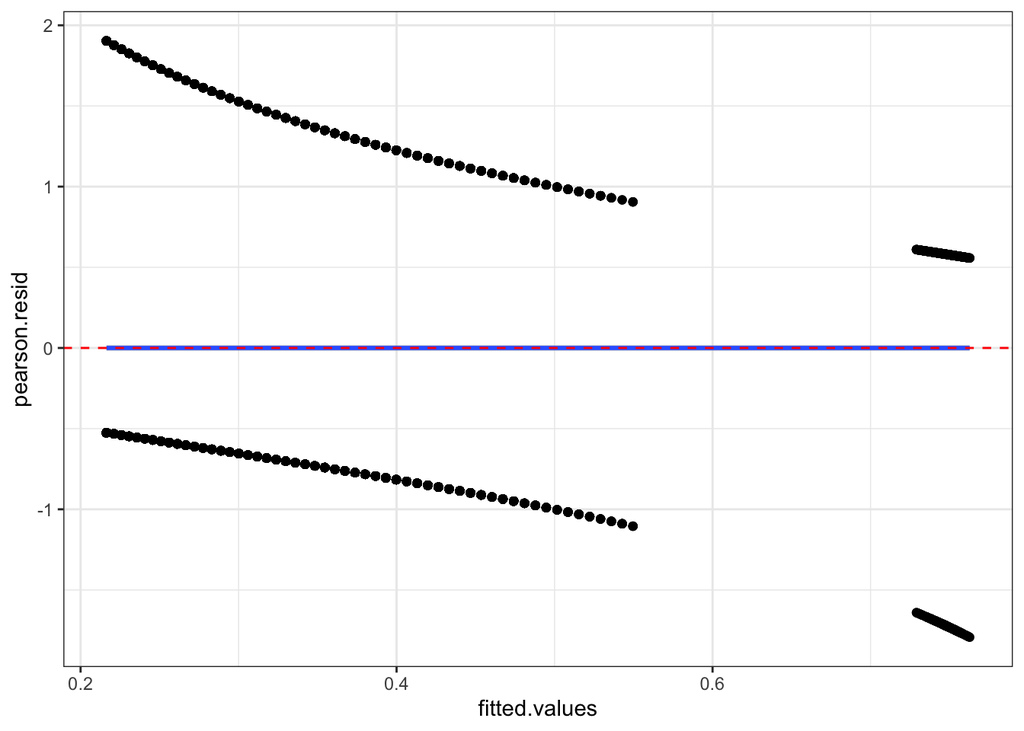

```r
ggplot(data = data1, aes(x = fitted.values, y = pearson.resid)) +
    theme_bw() +
    geom_point() +
    geom_smooth() +
    geom_abline(intercept = 0, slope = 0, color = "red", linetype = "dashed")
```

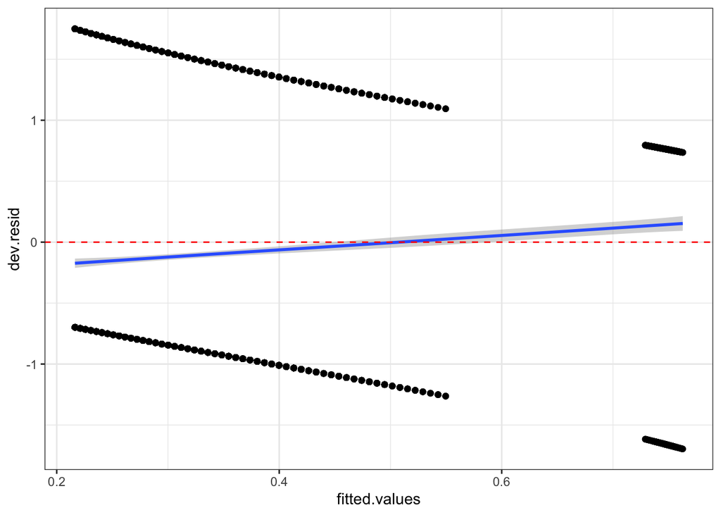

```r
ggplot(data = data1, aes(x = fitted.values, y = dev.resid)) +
    theme_bw() +
    geom_point() +
    geom_smooth() +
    geom_abline(intercept = 0, slope = 0, color = "red", linetype = "dashed")
```

No trend was observed based on Pearson residual, but an upward linear trend was observed based on deviance residual.

### 3. Is the Variance Model Correct? – Underdispersion or Overdispersion?

Compare empirical variance with variance estimated using Bernoulli distribution

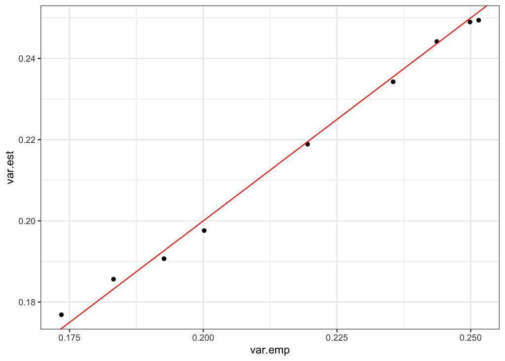

```r
varcomp = data1 %>% mutate(fitted.range = as.integer(cut(fitted.values, breaks=seq(0.2,0.8,by=0.05)))) %>%
    group_by(fitted.range) %>%
    summarize(var.emp = var(bigexp), var.est = mean(fitted.values*(1-fitted.values)))
ggplot(data = varcomp, aes(x = var.emp, y = var.est)) +
  theme_bw() +
  geom_point() +
  geom_abline(intercept = 0, slope = 1, color = "red")
```

Estimated variance aligns well with empirical variance - no underdispersion or overdispersion.

If there is underdispersion or overdisperson, the bootstrap can be used to estimate variance of the estimated logistic regression model coefficients.

### 4. Few data points don’t have great influence on results

Use DFITS and DBETAS, same as in the linear regression. See page 28 of the slides of 140.653 Lecture 10.